# Approximation of the Distribution function of $N(0,1)$

Jiaqi Chang

27 三月 2020

In order to demonstrate the process of approximation,I made a table with approximate values and true values drawn some box plots of the 100 approximation errors at each t for each n.

Finally,we can draw an conclude that as n gets bigger and bigger,approximation of the distribution function is getting closer and closer to the truth value.

# Math Equations

Monte Carlo method. They are often used in physical and mathematical problems and are most useful when it is difficult or impossible to use other approaches. Monte Carlo methods are mainly used in three problem classes: optimization, numerical integration, and generating draws from a probability distribution .

Here I will approximate the distribution function of $N(0,1)$ ,
$$\begin{align}
\Phi(t) = \int_{-\infty}^t\frac{1}{\sqrt{{2\pi}}}e^
{(-y^2)/2} \,{\rm d}y,
\end{align}$$
by the Monte Carlo methods:
$$\begin{align}
\hat{\Phi}(t) = \frac{1}{n}\sum_{i=1}^n I(X_i \leq t),
\end{align}$$
where $X_i$ is a random sample from $N(0,1)$, and $I(.)$ is the indicator function.

# The Analysis Process

```r
t=c(0,0.67,0.84,1.28,1.65,2.32,2.58,3.09,3.72)
n=c(100,1000,10000)
p=matrix(0,nrow=9,ncol=3)
for (i in 1:9)
  for(j in 1:3){
    num=rnorm(n[j],0,1)
    p[i,j]=mean(num<t[i])
  }
rownames(p)<-t
colnames(p)<-n
true_value<-c(pnorm(0),pnorm(0.67),pnorm(0.84),pnorm(1.28),pnorm(1.65),
           pnorm(2.32),pnorm(2.58),pnorm(3.09),pnorm(3.72))
p<-cbind(p,true_value)
p<-round(p,digits=3)
library(knitr)
library(magrittr)
library(kableExtra)
kable(p, booktabs=TRUE, caption='Comparison between approximate and true value') %>%
  kable_styling(bootstrap_options = "striped",full_width = F) %>%
 column_spec(1,bold=T)
```

Comparison between approximate and true value

|  | 100 | 1000 | 10000 | true_value |
| --- | --- | --- | --- | --- |
| 0 | 0.55 | 0.519 | 0.498 | 0.500 |
| 0.67 | 0.80 | 0.748 | 0.756 | 0.749 |
| 0.84 | 0.77 | 0.786 | 0.801 | 0.800 |
| 1.28 | 0.96 | 0.890 | 0.904 | 0.900 |
| 1.65 | 0.97 | 0.956 | 0.953 | 0.951 |
| 2.32 | 0.99 | 0.988 | 0.989 | 0.990 |
| 2.58 | 0.99 | 0.996 | 0.995 | 0.995 |
| 3.09 | 1.00 | 1.000 | 0.999 | 0.999 |
| 3.72 | 1.00 | 1.000 | 1.000 | 1.000 |

Second,I repeat the experiment 100 times.Draw box plots of the 100 approximation errors at each $t$ using ggplot2 for each $n$.

[output not shown]

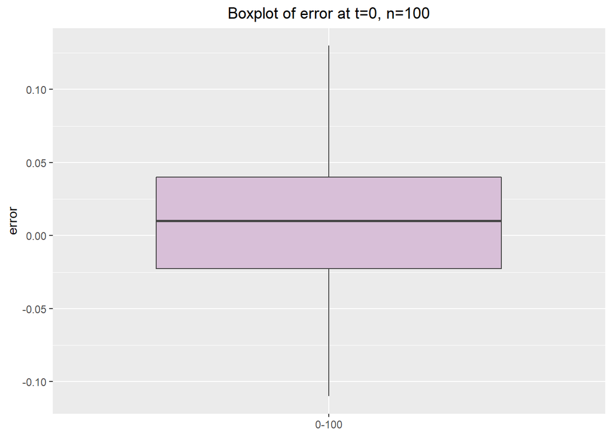

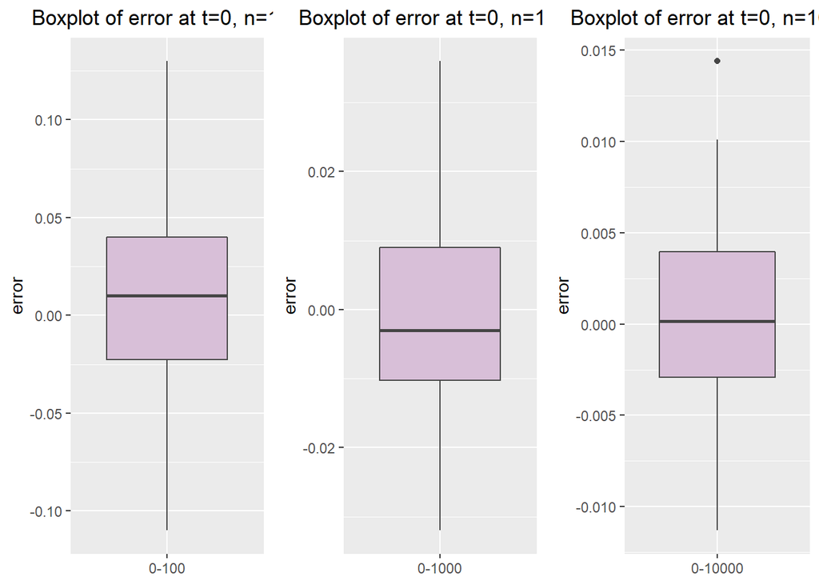

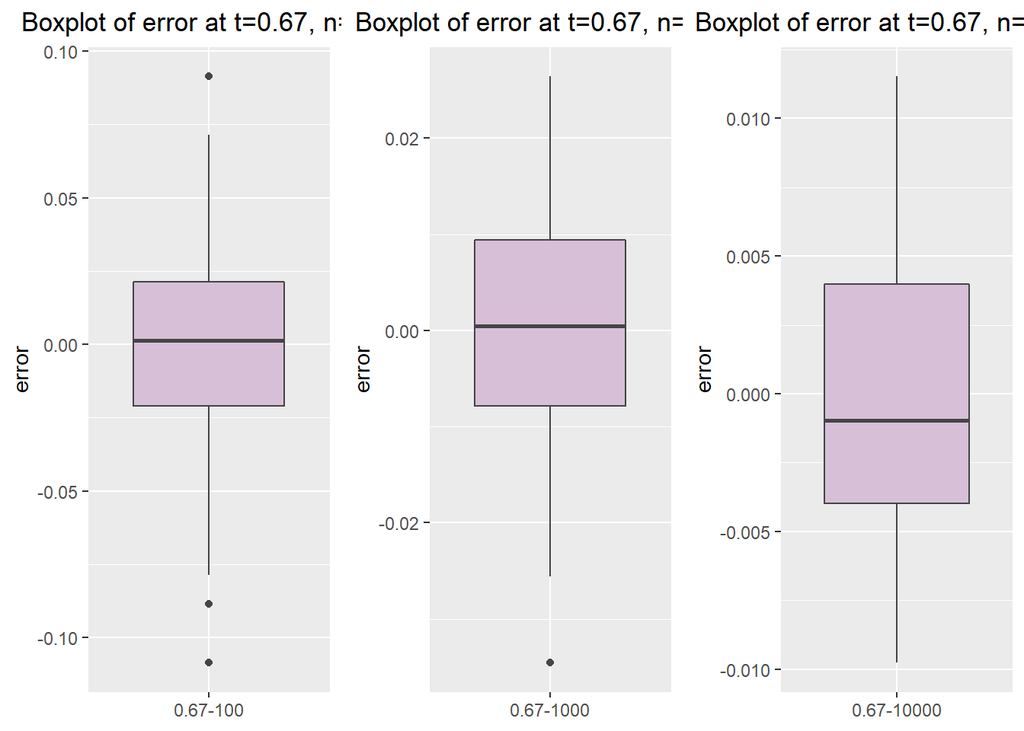

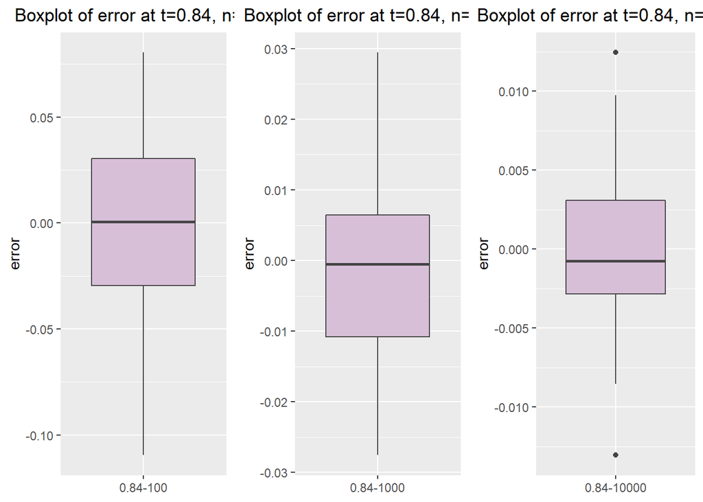

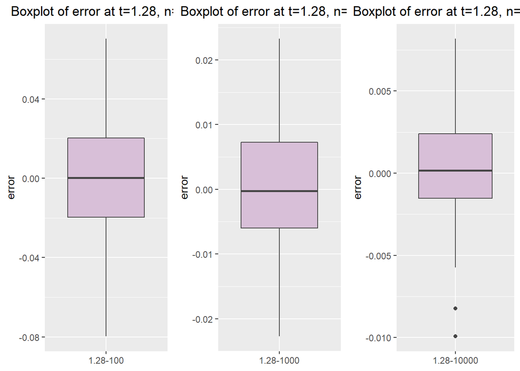

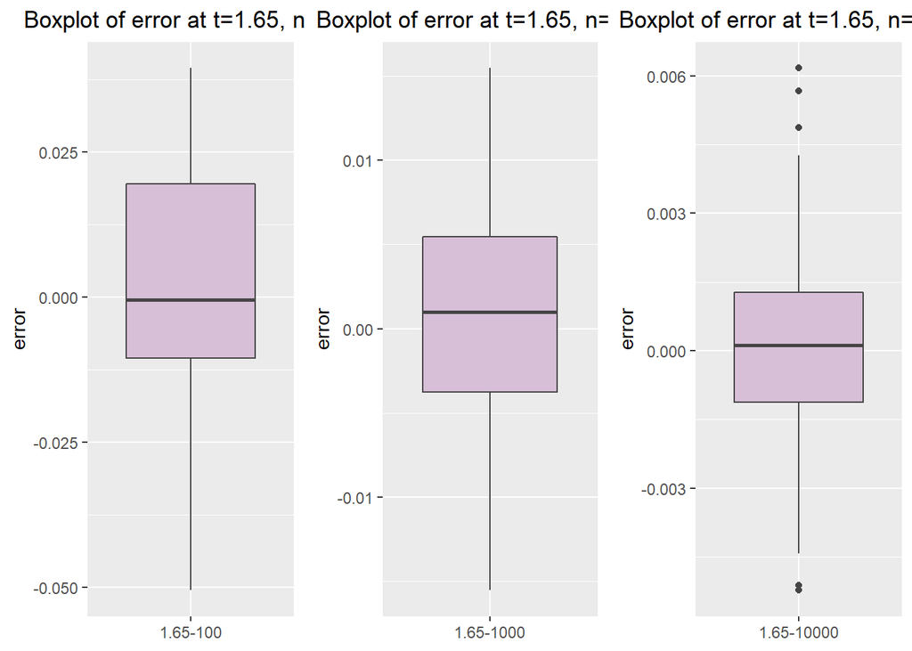

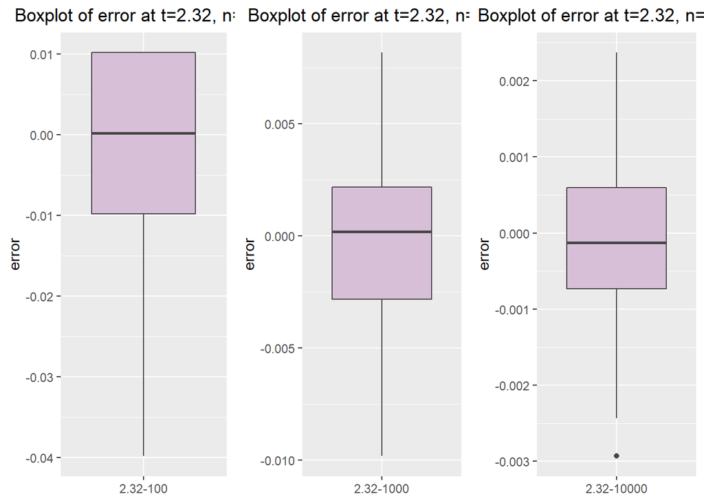

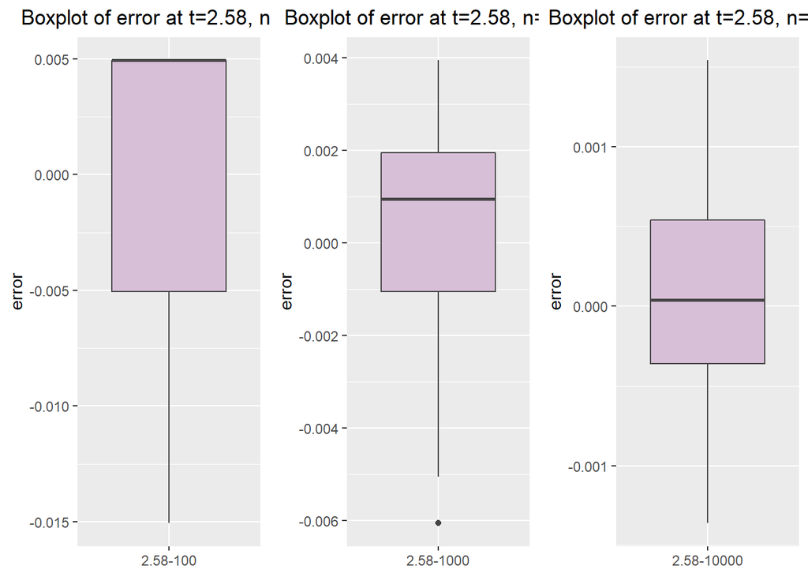

[figure not shown]

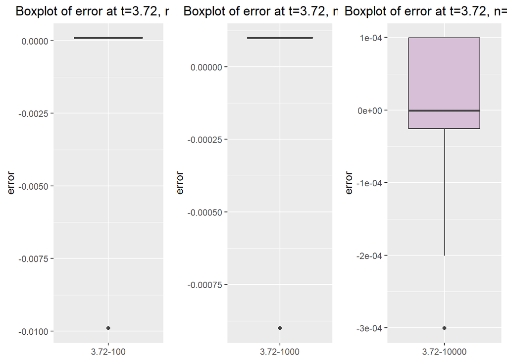

# Summary and Discussion

When n is a large number, the approximate value is approximately equal to the truth value.So,by using the Monte Carlo methods,we can generatie draws from a probability distribution.